# Day 1 and 2

Bryan Goodrich

January 3, 2017

## Day 1

This day I’m going to venture into an area I’m not so familiar with: generative models. Most of what I have been taught in machine learning has focused on typical discriminative models for learning. To me, I think generative models have so much more potential for really tapping into probability distributions and simulation capabilities of your data. I say this as I’m totally novice about it! Nevertheless, implementing naive bayes is not hard to do. What I wanted to see was how to show those conditional probabilities in the margin of the data.

Today we use the iris data set that ships with R.

For inspiration on how to set up the marginal plots, see http://www.statmethods.net/advgraphs/layout.html

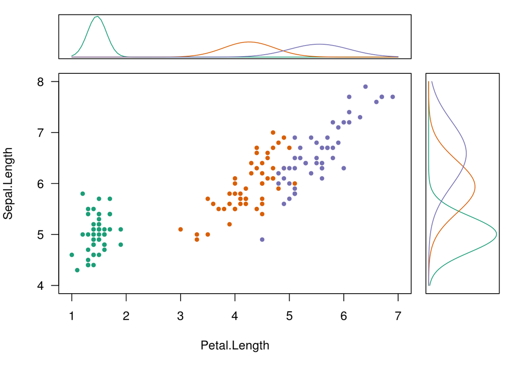

```r
library(e1071)  # naiveBayes
library(RColorBrewer) # brewer.pal



# foo
table_dnorm <- function(row, from, to, n = 101 ,...)
{
    xseq <- seq(from, to, length.out = n)
    dnorm(xseq, row[1], row[2], ...)
}

# Plots the PDF from a Naive Bayes conditional probability table
plot_density <- function(x, from, to, flip = FALSE, ...) {
    require(RColorBrewer)
    pal <- brewer.pal(3, 'Dark2')
    names(pal) <- sort(rownames(x))

    m <- apply(x, 1, table_dnorm, from = from, to = to)
    if (flip)
    {
        matplot(m, seq(nrow(m)), type = 'l', lty = 1, col = pal,
                xaxt = 'n', yaxt = 'n', xlab = '', ylab = '')
    } else
    {
        matplot(m, type = 'l', lty = 1, col = pal,
                xaxt = 'n', yaxt = 'n', xlab = '', ylab = '')
    }
    invisible(m)
}



# Example Data
data(iris)



# Fit the Naive Bayes Model
fit <- naiveBayes(Species ~ ., data = iris)

# For convenience
SL <- fit$tables$Sepal.Length
PL <- fit$tables$Petal.Length
SW <- fit$tables$Sepal.Width
PW <- fit$tables$Petal.Width

# See the marginals among sepal and petal lengths
par(fig = c(0.0, 0.8, 0.0, 0.8), mar = c(5, 4, 0, 0))
pal <- brewer.pal(3, 'Dark2')
names(pal) <- levels(iris$Species)
plot(Sepal.Length ~ Petal.Length, iris, col = pal[Species],
     pch = 20, las=1, xlim = c(1, 7), ylim = c(4, 8))

par(fig = c(0.0, 0.8, 0.8, 1.0), mar = c(1, 4, 1, 0), new = TRUE)
plot_density(PL, 1, 7)

par(fig = c(0.8, 1.0, 0.0, 0.8), mar = c(5, 1, 0, 1), new = TRUE)
plot_density(SL, 4, 8, flip = TRUE)
```

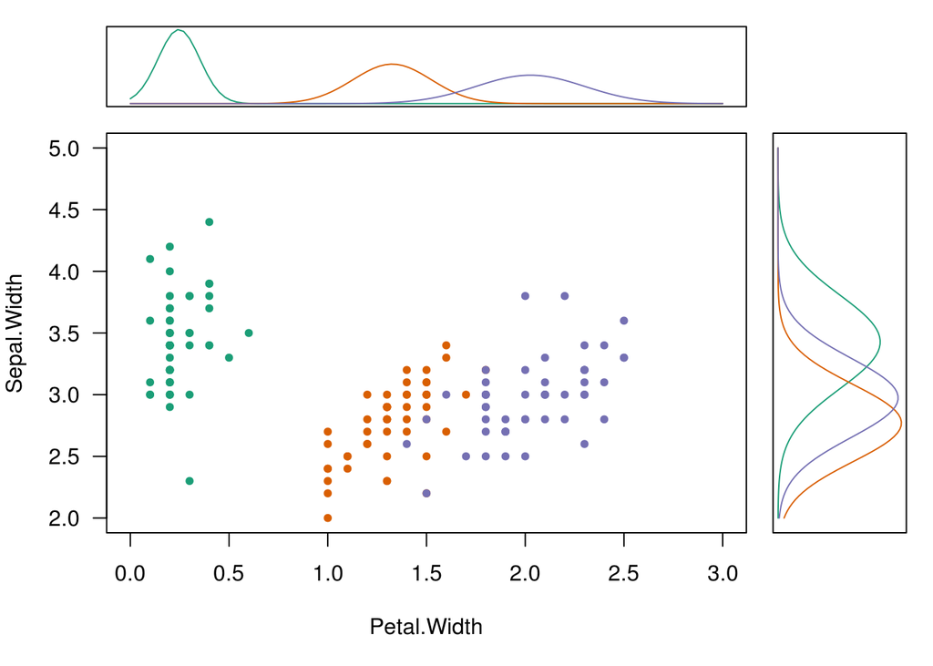

```r
# See the marginals among sepal and petal widths
par(fig = c(0.0, 0.8, 0.0, 0.8), mar = c(5, 4, 0, 0))
plot(Sepal.Width ~ Petal.Width, iris, col = pal[Species],
     pch = 20, las=1, xlim = c(0, 3), ylim = c(2, 5))

par(fig = c(0.0, 0.8, 0.8, 1.0), mar = c(1, 4, 1, 0), new = TRUE)
plot_density(PW, 0, 3)

par(fig = c(0.8, 1.0, 0.0, 0.8), mar = c(5, 1, 0, 1), new = TRUE)
plot_density(SW, 2, 5, flip = TRUE)
```

## Day 2

Here I want to explore working with a “nearest neighbor” model as represented in a KD-tree. This is a data structure I’ve worked on in my Data Structures class, and it is really neat (I’d like to port it into R some day). What the RANN library does is provide a way to get its functionality (efficient range searches) in a nearest neighbor model.

Since I currently work as a data scientist at an electricity utilty, I found some public data for a similar use case: find the nearest load shapes to a provided load shape (either between customers or within a customer across the year).

- [Data Source](http://en.openei.org/datasets/files/961/pub/)
- [Data File](http://en.openei.org/datasets/files/961/pub/RESIDENTIAL_LOAD_DATA_E_PLUS_OUTPUT/BASE/USA_CA_Sacramento.Exec.AP.724830_TMY3_BASE.csv)

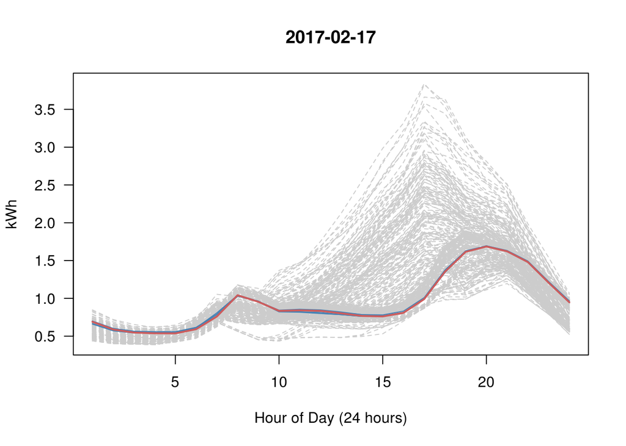

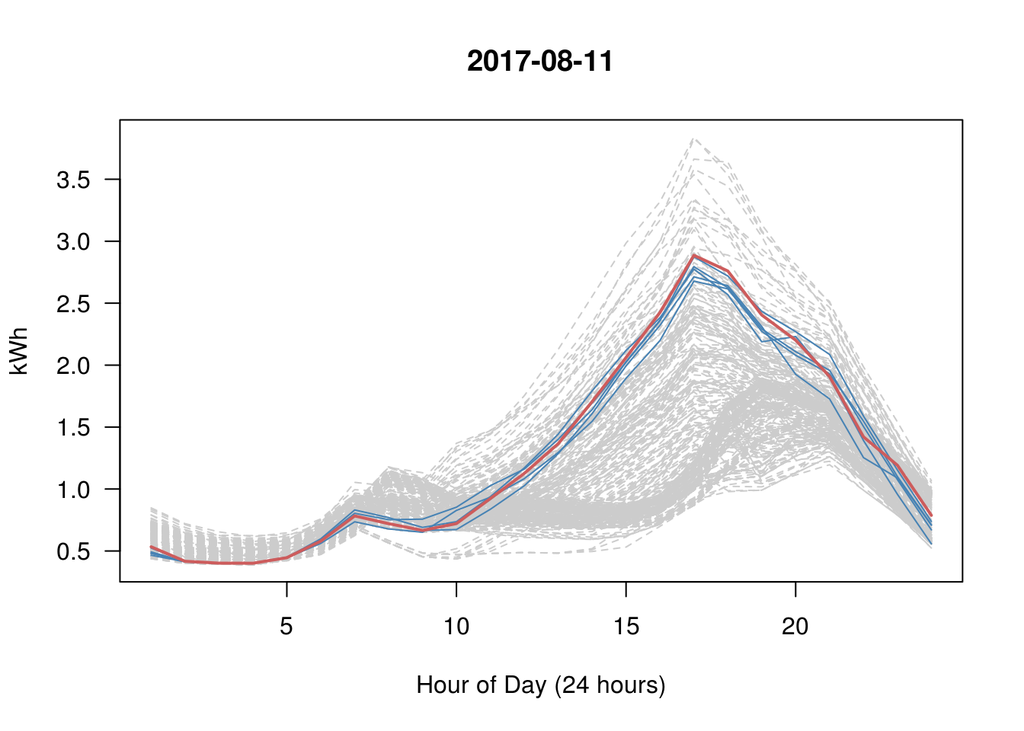

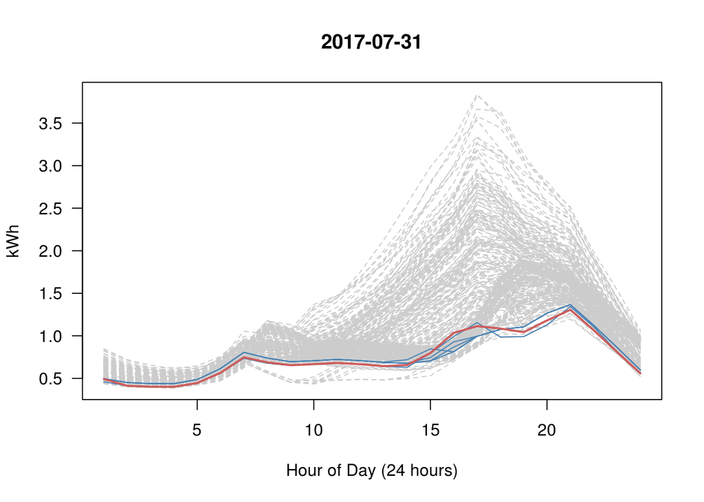

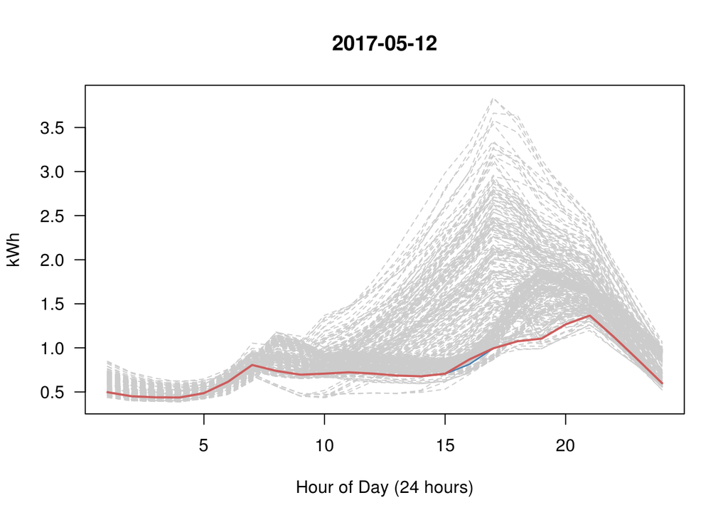

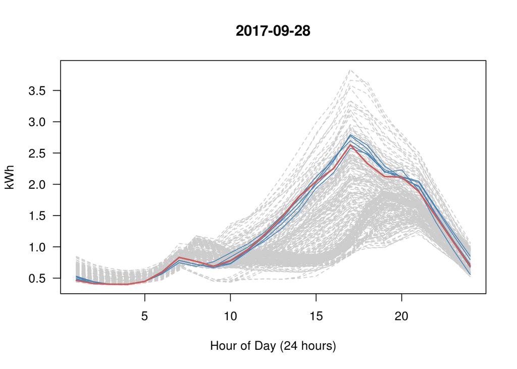

```r
library(RANN)  # nn
library(reshape2)  # dcast



# Custom Parser for Date.Time column
parser <- function(fmt)
{
    function(x)
    {
        # Define Return Object
        data.frame(
            # x[1] is an empty split from leading whitespace
            day  = as.Date(x[2], fmt),
            hour = as.numeric(substr(x[3], 1, 2))
        )
    }
}



# Import Today's Data
infile <- url("http://en.openei.org/datasets/files/961/pub/RESIDENTIAL_LOAD_DATA_E_PLUS_OUTPUT/BASE/USA_CA_Sacramento.Exec.AP.724830_TMY3_BASE.csv")
x <- read.csv(infile, as.is = TRUE)[1:2]  # Only using Electricity
names(x) <- c("datetime", "kwh")
dt <- do.call(rbind, lapply(strsplit(x$datetime, ' +'), parser('%m/%d')))

x <- data.frame(x, dt)  # Hourly Grain
y <- reshape2::dcast(x, day ~ hour, value.var = 'kwh')  # Daily Grain



# kd-tree search model
kd <- nn2(y[-1], k=6)  # k=5 with 1 for matching self



# Every Day vs Top 5 (blue) vs This Day (red)
# What happened with Sep 28?? That's really the nearest 5?
set.seed(600)
for (i in 1:5)  # Try 5 Random Days; Review Plots Afterwards
{
    p <- sample(1:365, 1)  # Choose a random day
    idx <- kd$nn.idx[p, -1]  # top5 similar days to p

    matplot(t(y[-1]), type = 'l', col = 'gray80', lty = 2, main = y$day[p],
            las = 1, xlab = "Hour of Day (24 hours)", ylab = "kWh")
    matlines(t(y[idx, -1]), col = 'steelblue', lty = 1)
    lines(t(y[p, -1]), col = 'indianred', lwd=2)
}
```